# Autogenous - LDna combined analysis

```r
cluster_6_all <- snps[snps$Scaffold %in% cluster_6$Scaffold, ]
head(cluster_6_all)
```

```
## # A tibble: 6 x 6
##   Scaffold SNP             Cm Position Allele1 Allele2
##   <chr>    <chr>        <int>    <dbl> <chr>   <chr>
## 1 1.152    AX-583496546     0    28493 T       C
## 2 1.152    AX-583496607     0    43318 A       G
## 3 1.152    AX-583499574     0    96763 G       A
## 4 1.152    AX-583499672     0   132155 T       G
## 5 1.152    AX-583499700     0   136348 A       G
## 6 1.152    AX-583499977     0   188640 T       A
```

However we need the other SNPs to know if the blocks are connected or not. Now we know what scaffolds the SNPs are located and we can check it

```r
cluster_14_all <- snps[snps$Scaffold %in% cluster_14$Scaffold, ]
head(cluster_14_all)
```

```
## # A tibble: 6 x 6
##   Scaffold SNP             Cm Position Allele1 Allele2
##   <chr>    <chr>        <int>    <dbl> <chr>   <chr>
## 1 2.22     AX-579445128     0    49751 G       A
## 2 2.22     AX-579445195     0    64564 A       T
## 3 2.22     AX-579443938     0   100572 A       G
## 4 2.22     AX-579445430     0   157266 G       T
## 5 2.22     AX-579445592     0   202795 T       A
## 6 2.22     AX-579444301     0   212193 C       T
```

Now we can create a new column and tag the SNPs that are linked

```r
# Creating the new column 'linked'
cluster_14_all <- cluster_14_all %>%
  mutate(linked = SNP %in% aut_ch2$`3215_0.78`)
head(cluster_14_all)
```

```
## # A tibble: 6 x 7
##   Scaffold SNP             Cm Position Allele1 Allele2 linked
##   <chr>    <chr>        <int>    <dbl> <chr>   <chr>   <lgl>
## 1 2.22     AX-579445128     0    49751 G       A       FALSE
## 2 2.22     AX-579445195     0    64564 A       T       FALSE
## 3 2.22     AX-579443938     0   100572 A       G       FALSE
## 4 2.22     AX-579445430     0   157266 G       T       FALSE
## 5 2.22     AX-579445592     0   202795 T       A       FALSE
## 6 2.22     AX-579444301     0   212193 C       T       FALSE
```

```r
# Creating the new column 'linked'
cluster_6_all <- cluster_6_all %>%
  mutate(linked = SNP %in% aut_ch1$`1971_0.64`)
head(cluster_6_all)
```

```
## # A tibble: 6 x 7
##   Scaffold SNP             Cm Position Allele1 Allele2 linked
##   <chr>    <chr>        <int>    <dbl> <chr>   <chr>   <lgl>
## 1 1.152    AX-583496546     0    28493 T       C       FALSE
## 2 1.152    AX-583496607     0    43318 A       G       FALSE
## 3 1.152    AX-583499574     0    96763 G       A       FALSE
## 4 1.152    AX-583499672     0   132155 T       G       FALSE
## 5 1.152    AX-583499700     0   136348 A       G       FALSE
## 6 1.152    AX-583499977     0   188640 T       A       FALSE
```

Lets check how many linked SNPs we have and how many aren’t

```r
count_linked <- cluster_14_all %>%
  group_by(linked) %>%
  summarise(count = n())
count_linked
```

```
## # A tibble: 2 x 2
##   linked count
##   <lgl>  <int>
## 1 FALSE   2649
## 2 TRUE     324
```

```r
count_linked <- cluster_6_all %>%
  group_by(linked) %>%
  summarise(count = n())
count_linked
```

```
## # A tibble: 2 x 2
##   linked count
##   <lgl>  <int>
## 1 FALSE   1268
## 2 TRUE      90
```

Get the 157 outliers

```r
snps_157 <-
  read.table(
    here("output", "pcadapt", "outlier_157_SNPs.txt"),
    stringsAsFactors = FALSE
    )

# Get the 157 SNPs
snps_157b <- cluster_14_all |>
  filter(SNP %in% snps_157$V1)

head(snps_157b)
```

```
## # A tibble: 6 x 7
##   Scaffold SNP             Cm Position Allele1 Allele2 linked
##   <chr>    <chr>        <int>    <dbl> <chr>   <chr>   <lgl>
## 1 2.22     AX-579474142     0  6075268 T       C       FALSE
## 2 2.22     AX-579474650     0  6122430 A       G       FALSE
## 3 2.22     AX-579509845     0 13142038 A       T       FALSE
## 4 2.36     AX-579556477     0  1062758 T       C       FALSE
## 5 2.36     AX-579560686     0  2139679 C       T       FALSE
## 6 2.36     AX-579564292     0  2894537 A       G       FALSE
```

```r
# Get the 157 SNPs
snps_157c <- cluster_6_all |>
  filter(SNP %in% snps_157$V1)

head(snps_157c)
```

```
## # A tibble: 6 x 7
##   Scaffold SNP             Cm Position Allele1 Allele2 linked
##   <chr>    <chr>        <int>    <dbl> <chr>   <chr>   <lgl>
## 1 1.152    AX-583504302     0  1149628 A       G       TRUE
## 2 1.152    AX-583514148     0  2847295 T       C       FALSE
## 3 1.152    AX-583515734     0  3903190 A       G       FALSE
## 4 1.152    AX-583518586     0  3966380 T       C       FALSE
## 5 1.152    AX-583518994     0  4024772 A       G       FALSE
## 6 1.152    AX-583516491     0  4057192 T       C       FALSE
```

Plot it

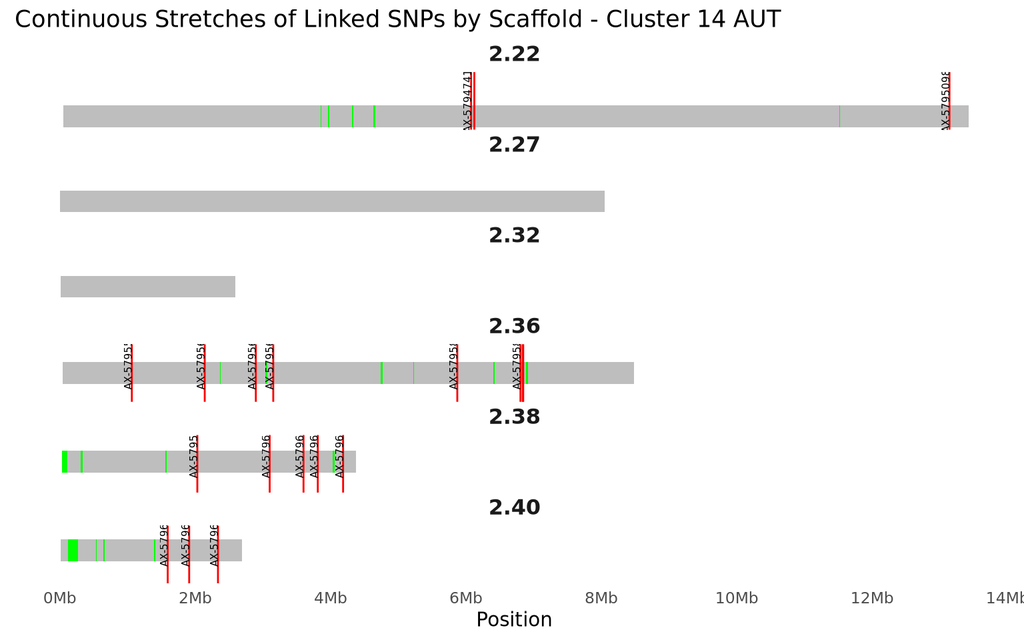

```r
# Function to format numbers as Mb
label_mb <- function(x) {
  sprintf("%.0fMb", x / 1e6)
}


# Calculate the start and end positions for each stretch of TRUE or FALSE
rect_data <- cluster_14_all %>%
  arrange(Scaffold, Position) %>%
  mutate(change = linked != lag(linked, default = first(linked))) %>%
  group_by(Scaffold) %>%
  mutate(group_id = cumsum(change)) %>%
  group_by(Scaffold, group_id, linked) %>%
  summarize(start = min(Position), end = max(Position), .groups = 'drop') %>%
  ungroup()

# Plotting using geom_rect
ggplot(rect_data, aes(xmin = start, xmax = end, ymin = as.numeric(Scaffold) - 0.1, ymax = as.numeric(Scaffold) + 0.1)) +
  # Add a background layer for each scaffold with gray color
  geom_rect(data = rect_data %>% group_by(Scaffold) %>%
            summarize(start = min(start), end = max(end), .groups = 'drop'),
            aes(xmin = start, xmax = end, ymin = as.numeric(Scaffold) - 0.1, ymax = as.numeric(Scaffold) + 0.1),
            fill = "gray", inherit.aes = FALSE) +
  # Add the TRUE stretches
  geom_rect(aes(fill = linked), data = rect_data %>% filter(linked == TRUE)) +
  scale_fill_manual(values = c("TRUE" = "green")) +
  facet_wrap(~ Scaffold, scales = "fixed", ncol = 1) +
  geom_vline(data = snps_157b, aes(xintercept = Position, color = SNP), linetype = "solid", color = "red") +
  geom_text(data = snps_157b, aes(x = Position, y = as.numeric(Scaffold) + 0.2, label = SNP), inherit.aes = FALSE, angle = 90, vjust = 0, size = 2, check_overlap = TRUE) +
  theme_minimal() +
  theme(
    axis.title.y = element_blank(),
    axis.text.y = element_blank(),
    axis.ticks.y = element_blank(),
    panel.spacing = unit(0.1, "lines"),
    panel.grid.major = element_blank(),
    panel.grid.minor = element_blank(),
    strip.text = element_text(size = 12, face = "bold", hjust = 0.5, margin = margin(t = 1, b = 5))
  ) +
  scale_x_continuous(labels = label_mb, breaks = scales::pretty_breaks(n = 6)) +
  labs(x = "Position", title = "Continuous Stretches of Linked SNPs by Scaffold - Cluster 14 AUT", fill = "Linked") +
  guides(fill = "none")
```

```r
# Save Venn diagram to PDF
output_path <- here("output", "ldna", "figures", "cluster_14_aut_scaffolds.pdf")
ggsave(output_path, height = 5, width = 8, units = "in")
```

To make sure the windows appear even if they are small

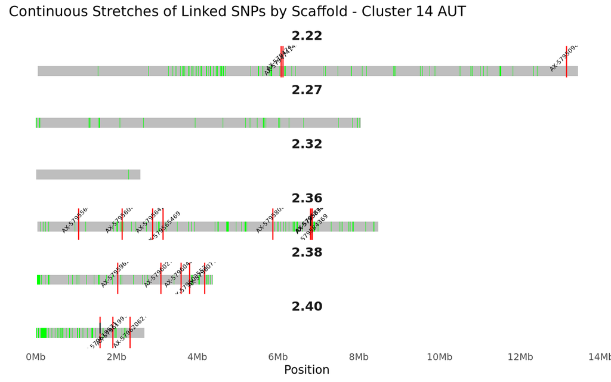

```r
# Set a minimum width for the windows
min_width <- 1e4  # for example, 1 million base pairs

# Adjust the rect_data calculation
rect_data <- cluster_14_all %>%
  arrange(Scaffold, Position) %>%
  mutate(change = linked != lag(linked, default = first(linked))) %>%
  group_by(Scaffold) %>%
  mutate(group_id = cumsum(change)) %>%
  group_by(Scaffold, group_id, linked) %>%
  summarize(start = min(Position), end = max(Position), .groups = 'drop') %>%
  ungroup() %>%
  mutate(width = end - start,
         adjusted_end = ifelse(width < min_width, start + min_width, end))

# Plotting using geom_rect with adjusted ends
ggplot(rect_data, aes(xmin = start, xmax = adjusted_end, ymin = as.numeric(Scaffold) - 0.1, ymax = as.numeric(Scaffold) + 0.1)) +
  geom_rect(data = rect_data %>% group_by(Scaffold) %>%
            summarize(start = min(start), end = max(adjusted_end), .groups = 'drop'),
            aes(xmin = start, xmax = end, ymin = as.numeric(Scaffold) - 0.1, ymax = as.numeric(Scaffold) + 0.1),
            fill = "gray", inherit.aes = FALSE) +
  geom_rect(aes(fill = linked), data = rect_data %>% filter(linked == TRUE)) +
  scale_fill_manual(values = c("TRUE" = "green")) +
  facet_wrap(~ Scaffold, scales = "fixed", ncol = 1) +
  theme_minimal() +
  geom_vline(data = snps_157b, aes(xintercept = Position, color = SNP), linetype = "solid", color = "red") +
  geom_text_repel(data = snps_157b, aes(x = Position, y = as.numeric(Scaffold) + 0.2, label = SNP),
                  inherit.aes = FALSE, angle = 45, size = 2,
                  nudge_y = 0.1,   # Adjust this value as needed
                  direction = "y") +
  theme(axis.title.y = element_blank(), axis.text.y = element_blank(), axis.ticks.y = element_blank(), panel.spacing = unit(0.1, "lines"),
        panel.grid.major = element_blank(), panel.grid.minor = element_blank(),
        strip.text = element_text(size = 12, face = "bold", hjust = 0.5)) +
  scale_x_continuous(labels = label_mb, breaks = scales::pretty_breaks(n = 6)) +
  labs(x = "Position", title = "Continuous Stretches of Linked SNPs by Scaffold - Cluster 14 AUT", fill = "Linked") +
  guides(fill = "none")
```

```r
# Save Venn diagram to PDF
output_path <- here("output", "ldna", "figures", "cluster_14_aut_scaffolds_with_small_windows.pdf")
ggsave(output_path, height = 5, width = 8, units = "in")
```

Cluster 6

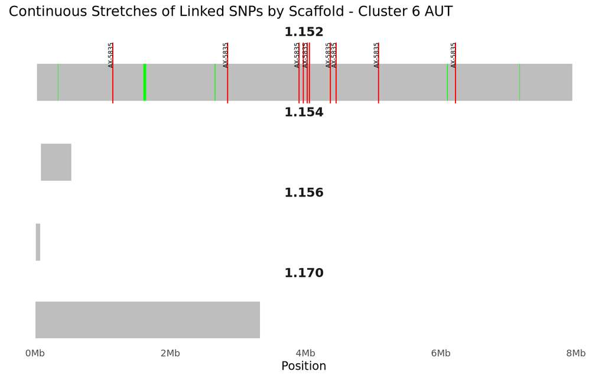

```r
# Function to format numbers as Mb
label_mb <- function(x) {
  sprintf("%.0fMb", x / 1e6)
}


# Calculate the start and end positions for each stretch of TRUE or FALSE
rect_data <- cluster_6_all %>%
  arrange(Scaffold, Position) %>%
  mutate(change = linked != lag(linked, default = first(linked))) %>%
  group_by(Scaffold) %>%
  mutate(group_id = cumsum(change)) %>%
  group_by(Scaffold, group_id, linked) %>%
  summarize(start = min(Position), end = max(Position), .groups = 'drop') %>%
  ungroup()

# Plotting using geom_rect
ggplot(rect_data, aes(xmin = start, xmax = end, ymin = as.numeric(Scaffold) - 0.1, ymax = as.numeric(Scaffold) + 0.1)) +
  # Add a background layer for each scaffold with gray color
  geom_rect(data = rect_data %>% group_by(Scaffold) %>%
            summarize(start = min(start), end = max(end), .groups = 'drop'),
            aes(xmin = start, xmax = end, ymin = as.numeric(Scaffold) - 0.1, ymax = as.numeric(Scaffold) + 0.1),
            fill = "gray", inherit.aes = FALSE) +
  # Add the TRUE stretches
  geom_rect(aes(fill = linked), data = rect_data %>% filter(linked == TRUE)) +
  scale_fill_manual(values = c("TRUE" = "green")) +
  facet_wrap(~ Scaffold, scales = "fixed", ncol = 1) +
  geom_vline(data = snps_157c, aes(xintercept = Position, color = SNP), linetype = "solid", color = "red") +
  geom_text(data = snps_157c, aes(x = Position, y = as.numeric(Scaffold) + 0.2, label = SNP), inherit.aes = FALSE, angle = 90, vjust = 0, size = 2, check_overlap = TRUE) +
  theme_minimal() +
  theme(
    axis.title.y = element_blank(),
    axis.text.y = element_blank(),
    axis.ticks.y = element_blank(),
    panel.spacing = unit(0.1, "lines"),
    panel.grid.major = element_blank(),
    panel.grid.minor = element_blank(),
    strip.text = element_text(size = 12, face = "bold", hjust = 0.5, margin = margin(t = 1, b = 5))
  ) +
  scale_x_continuous(labels = label_mb, breaks = scales::pretty_breaks(n = 6)) +
  labs(x = "Position", title = "Continuous Stretches of Linked SNPs by Scaffold - Cluster 6 AUT", fill = "Linked") +
  guides(fill = "none")
```

```r
# Save Venn diagram to PDF
output_path <- here("output", "ldna", "figures", "cluster_6_aut_scaffolds.pdf")
ggsave(output_path, height = 5, width = 8, units = "in")
```

To make sure the windows appear even if they are small

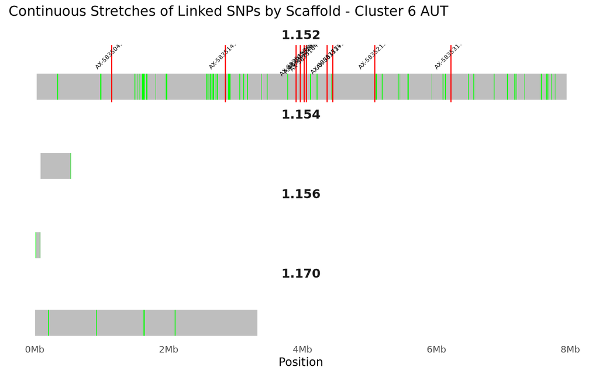

```r
# Set a minimum width for the windows
min_width <- 1e4  # for example, 1 million base pairs

# Adjust the rect_data calculation
rect_data <- cluster_6_all %>%
  arrange(Scaffold, Position) %>%
  mutate(change = linked != lag(linked, default = first(linked))) %>%
  group_by(Scaffold) %>%
  mutate(group_id = cumsum(change)) %>%
  group_by(Scaffold, group_id, linked) %>%
  summarize(start = min(Position), end = max(Position), .groups = 'drop') %>%
  ungroup() %>%
  mutate(width = end - start,
         adjusted_end = ifelse(width < min_width, start + min_width, end))

# Plotting using geom_rect with adjusted ends
ggplot(rect_data, aes(xmin = start, xmax = adjusted_end, ymin = as.numeric(Scaffold) - 0.1, ymax = as.numeric(Scaffold) + 0.1)) +
  geom_rect(data = rect_data %>% group_by(Scaffold) %>%
            summarize(start = min(start), end = max(adjusted_end), .groups = 'drop'),
            aes(xmin = start, xmax = end, ymin = as.numeric(Scaffold) - 0.1, ymax = as.numeric(Scaffold) + 0.1),
            fill = "gray", inherit.aes = FALSE) +
  geom_rect(aes(fill = linked), data = rect_data %>% filter(linked == TRUE)) +
  scale_fill_manual(values = c("TRUE" = "green")) +
  facet_wrap(~ Scaffold, scales = "fixed", ncol = 1) +
  theme_minimal() +
  geom_vline(data = snps_157c, aes(xintercept = Position, color = SNP), linetype = "solid", color = "red") +
  geom_text_repel(data = snps_157c, aes(x = Position, y = as.numeric(Scaffold) + 0.2, label = SNP),
                  inherit.aes = FALSE, angle = 45, size = 2,
                  nudge_y = 0.1,   # Adjust this value as needed
                  direction = "y") +
  theme(axis.title.y = element_blank(), axis.text.y = element_blank(), axis.ticks.y = element_blank(), panel.spacing = unit(0.1, "lines"),
        panel.grid.major = element_blank(), panel.grid.minor = element_blank(),
        strip.text = element_text(size = 12, face = "bold", hjust = 0.5)) +
  scale_x_continuous(labels = label_mb, breaks = scales::pretty_breaks(n = 6)) +
  labs(x = "Position", title = "Continuous Stretches of Linked SNPs by Scaffold - Cluster 6 AUT", fill = "Linked") +
  guides(fill = "none")
```

```r
# Save Venn diagram to PDF
output_path <- here("output", "ldna", "figures", "cluster_6_aut_scaffolds_with_small_windows.pdf")
ggsave(output_path, height = 5, width = 8, units = "in")
```

Calculate size

```r
# Calculate the length of each stretch
rect_data <- rect_data %>%
  mutate(length = end - start + 1)

# Calculate average sizes for TRUE and FALSE stretches
average_sizes <- rect_data %>%
  group_by(linked) %>%
  summarize(average_size = mean(length))

# Display the average sizes
print(average_sizes)
```

```
## # A tibble: 2 x 2
##   linked average_size
##   <lgl>         <dbl>
## 1 FALSE       132584.
## 2 TRUE          1015.
```

We can also check what genes are in these scaffolds.

Import the data

```r
snps_genes_chr <- readRDS(here("output", "ldna", "snps_genes_chr.rds"))
```

The expression data

```r
gene_expression <- read_delim(here("data", "files","MANvsAUTO_sig_mRNAs.csv"), delim = ",", col_names = TRUE, show_col_types = FALSE) |>
  dplyr::select(
    gene,log2FoldChange
  ) |>
  dplyr::rename(
    Gene_ID = gene
  )
head(gene_expression)
```

```
## # A tibble: 6 x 2
##   Gene_ID      log2FoldChange
##   <chr>                 <dbl>
## 1 LOC115262812         -10.5
## 2 LOC109401291          -9.19
## 3 LOC109397830           8.73
## 4 LOC115264022           8.56
## 5 LOC115260314           8.51
## 6 LOC115258723           8.39
```

For example, what genes are in the cluster 14, so we can check what genes are in these scaffolds or more specifically what SNPs are in the genes

First, what genes are in these scaffolds?

```r
cluster_14_genes <- snps_genes_chr[snps_genes_chr$Scaffold %in% cluster_14_all$Scaffold, ]

# How many genes in the scaffolds
length(unique(cluster_14_genes$Gene_ID))
```

```
## [1] 321
```

Now lets check what genes have the linked SNPs

```r
cluster_14_snps2 <- snps_genes_chr[snps_genes_chr$SNP %in% aut_ch2$`3215_0.78`, ]

# How many genes with SNPs from the ld block
length(unique(cluster_14_snps2$Gene_ID))
```

```
## [1] 109
```

Save as Excel file

```r
# Save the data frame to an Excel file
write_xlsx(cluster_14_snps2, here("output", "ldna", "cluster_14_snps2.xlsx"))
```

We can count how many linked SNPs per gene

```r
# Count the number of SNPs for each Gene_ID
snp_count_per_gene <- cluster_14_snps2 %>%
  group_by(Gene_ID) %>%
  summarise(SNP_count = n())

# View the first few rows of the result
head(snp_count_per_gene)
```

```
## # A tibble: 6 x 2
##   Gene_ID      SNP_count
##   <chr>            <int>
## 1 LOC109397326         1
## 2 LOC109397337         1
## 3 LOC109397339         1
## 4 LOC109397340         1
## 5 LOC109397344         2
## 6 LOC109397369         4
```

Save as Excel file

```r
# Save the data frame to an Excel file
write_xlsx(snp_count_per_gene, here("output", "ldna", "snp_count_per_gene.xlsx"))
```

Now we can check how many DE genes are among the 109 genes that have SNPs on the cluster 14

```r
cluster_14_snps3 <- cluster_14_snps2[cluster_14_snps2$Gene_ID %in% gene_expression$Gene_ID, ]

# How many genes in the scaffolds
length(unique(cluster_14_snps3$Gene_ID))
```

```
## [1] 3
```

```r
unique(cluster_14_snps3$Gene_ID)
```

```
## [1] "LOC109415738" "LOC109415743" "LOC109414739"
```

Get the 17 SNPs position

```r
# Get the 17 SNPs
genes_17_snps <- snps_genes_chr |>
  dplyr::filter(SNP %in% snps_157b$SNP)

genes_17_snps <- snps_genes_chr[snps_genes_chr$SNP %in% snps_157b$SNP, ]

head(genes_17_snps)
```

```
## # A tibble: 6 x 8
##   SNP          Chromosome Position_chr Scaffold Position Gene_ID    Start    End
##   <chr>        <chr>             <dbl> <chr>       <dbl> <chr>      <dbl>  <dbl>
## 1 AX-579474142 2             368006161 2.22      6075268 LOC10941~ 6.07e6 6.08e6
## 2 AX-579474650 2             368053323 2.22      6122430 LOC10941~ 6.12e6 6.19e6
## 3 AX-579509845 2             375072931 2.22     13142038 LOC10939~ 1.25e7 1.31e7
## 4 AX-579556477 2             390614565 2.36      1062758 LOC10939~ 9.66e5 1.06e6
## 5 AX-579580051 2             395422791 2.36      5870984 LOC10940~ 5.87e6 5.90e6
## 6 AX-579584369 2             396355776 2.36      6803969 LOC10941~ 6.71e6 6.82e6
```

Save as Excel file

```r
# Save the data frame to an Excel file
write_xlsx(genes_17_snps, here("output", "ldna", "cluster_14_17_snps.xlsx"))
```

Get the SNPs for which we do not have genes

```r
genes_17_snps2 <- snps_157b |>
  dplyr::filter(!(SNP %in% genes_17_snps$SNP))
head(genes_17_snps2)
```

```
## # A tibble: 6 x 7
##   Scaffold SNP             Cm Position Allele1 Allele2 linked
##   <chr>    <chr>        <int>    <dbl> <chr>   <chr>   <lgl>
## 1 2.36     AX-579560686     0  2139679 C       T       FALSE
## 2 2.36     AX-579564292     0  2894537 A       G       FALSE
## 3 2.36     AX-579565469     0  3152089 A       T       FALSE
## 4 2.38     AX-579596233     0  2030415 A       G       FALSE
## 5 2.38     AX-579602153     0  3099174 G       A       FALSE
## 6 2.38     AX-579604213     0  3599115 T       C       FALSE
```

```r
write.table(
  snps_157b,
  file      = here(
    "output", "ldna", "snps_157b.txt"
  ),
  sep       = "\t",
  row.names = FALSE,
  col.names = FALSE,
  quote     = FALSE
)
```

## 8. Cluster gene intersection with differentially expressed genes

This section identifies genes within the two major LD clusters (cluster 14 on chromosome 2 and cluster 6 on chromosome 1) and checks whether any overlap with differentially expressed genes from the NON-AUTO vs AUTO comparison.

The gene coordinate data (`snps_genes_chr.rds`) and expression data (`snps_expression.rds`) were generated in File S5.

### 8.1 Cluster 14 genes

```r
snps_genes_chr <-
  readRDS(
    file = here(
      "output", "ldna", "snps_genes_chr.rds"
      )
    )
head(snps_genes_chr)
```

```
## # A tibble: 6 x 8
##   SNP          Chromosome Position_chr Scaffold Position Gene_ID    Start    End
##   <chr>        <chr>             <dbl> <chr>       <dbl> <chr>      <dbl>  <dbl>
## 1 AX-581444870 1                 97856 1.1         97856 LOC10939~  64508 102530
## 2 AX-583033342 1                315059 1.1        315059 LOC10943~ 310594 316608
## 3 AX-583035163 1                315386 1.1        315386 LOC10943~ 310594 316608
## 4 AX-583033356 1                315674 1.1        315674 LOC10943~ 310594 316608
## 5 AX-583035257 1                442875 1.10        91677 LOC10940~  66918 192829
## 6 AX-583035268 1                462944 1.10       111746 LOC10940~  66918 192829
```

```r
snps_expression <-
  readRDS(
    here(
      "output", "ldna", "snps_expression.rds"
      )
    )
head(snps_expression)
```

```
## # A tibble: 6 x 9
##   SNP          Chromosome Position_chr Scaffold Position Gene_ID    Start    End
##   <chr>        <chr>             <dbl> <chr>       <dbl> <chr>      <dbl>  <dbl>
## 1 AX-583050970 1               3777633 1.10      3426435 LOC10942~ 3.42e6 3.43e6
## 2 AX-583052853 1               3777864 1.10      3426666 LOC10942~ 3.42e6 3.43e6
## 3 AX-583051011 1               3779183 1.10      3427985 LOC10942~ 3.42e6 3.43e6
## 4 AX-583052887 1               3793314 1.10      3442116 LOC10942~ 3.44e6 3.47e6
## 5 AX-583051025 1               3793653 1.10      3442455 LOC10942~ 3.44e6 3.47e6
## 6 AX-583052920 1               3794185 1.10      3442987 LOC10942~ 3.44e6 3.47e6
## # i 1 more variable: log2FoldChange <dbl>
```

```r
cluster_14_SNPs <-
  cluster_14 |>
  select(
    SNP
  )

head(cluster_14_SNPs)
```

```
## # A tibble: 6 x 1
##   SNP
##   <chr>
## 1 AX-579450486
## 2 AX-579456609
## 3 AX-579459157
## 4 AX-579459504
## 5 AX-579459790
## 6 AX-579461404
```

##### 8.1.1 Genes from coding regions

```r
genes_cluster_14 <- inner_join(cluster_14_SNPs, snps_genes_chr, by = "SNP", suffix = c("", ""))

head(genes_cluster_14)
```

```
## # A tibble: 6 x 8
##   SNP          Chromosome Position_chr Scaffold Position Gene_ID    Start    End
##   <chr>        <chr>             <dbl> <chr>       <dbl> <chr>      <dbl>  <dbl>
## 1 AX-579450486 2             363469720 2.22      1538827 LOC10941~ 1.54e6 1.55e6
## 2 AX-579459504 2             365315778 2.22      3384885 LOC11525~ 3.37e6 4.60e6
## 3 AX-579459790 2             365379266 2.22      3448373 LOC11525~ 3.37e6 4.60e6
## 4 AX-579459790 2             365379266 2.22      3448373 LOC11526~ 3.45e6 3.45e6
## 5 AX-579461404 2             365421089 2.22      3490196 LOC11525~ 3.37e6 4.60e6
## 6 AX-579461838 2             365507367 2.22      3576474 LOC11525~ 3.37e6 4.60e6
```

```r
write_xlsx(
  genes_cluster_14,
  here(
    "output", "ldna","genes_cluster_14.xlsx"
    )
  )
```

##### 8.1.2 Genes with differential expression

```r
DE_genes_cluster_14 <- inner_join(cluster_14_SNPs, snps_expression, by = "SNP", suffix = c("", ""))

head(DE_genes_cluster_14)
```

```
## # A tibble: 4 x 9
##   SNP          Chromosome Position_chr Scaffold Position Gene_ID    Start    End
##   <chr>        <chr>             <dbl> <chr>       <dbl> <chr>      <dbl>  <dbl>
## 1 AX-579585547 2             396531676 2.36      6979869 LOC10941~ 6.98e6 7.19e6
## 2 AX-579588768 2             397394228 2.36      7842421 LOC10941~ 7.84e6 7.84e6
## 3 AX-579598791 2             401278130 2.38      2679893 LOC10941~ 2.67e6 2.68e6
## 4 AX-579598805 2             401278614 2.38      2680377 LOC10941~ 2.67e6 2.68e6
## # i 1 more variable: log2FoldChange <dbl>
```

```r
write_xlsx(
  DE_genes_cluster_14,
  here(
    "output", "ldna","DE_genes_cluster_14.xlsx"
    )
  )
```

### 8.2 Cluster 6 genes

```r
cluster_6_SNPs <-
  cluster_6 |>
  select(
    SNP
  )

head(cluster_6_SNPs)
```

```
## # A tibble: 6 x 1
##   SNP
##   <chr>
## 1 AX-583500511
## 2 AX-583500520
## 3 AX-583503153
## 4 AX-583500379
## 5 AX-583503258
## 6 AX-583504302
```

##### 8.2.1 Genes from coding regions

```r
genes_cluster_6 <- inner_join(cluster_6_SNPs, snps_genes_chr, by = "SNP", suffix = c("", ""))

head(genes_cluster_6)
```

```
## # A tibble: 6 x 8
##   SNP          Chromosome Position_chr Scaffold Position Gene_ID    Start    End
##   <chr>        <chr>             <dbl> <chr>       <dbl> <chr>      <dbl>  <dbl>
## 1 AX-583503153 1             138373561 1.152      977944 LOC11526~ 9.77e5 9.79e5
## 2 AX-583500379 1             138374084 1.152      978467 LOC11526~ 9.77e5 9.79e5
## 3 AX-583503258 1             138383242 1.152      987625 LOC11525~ 9.79e5 9.89e5
## 4 AX-583503279 1             138887257 1.152     1491640 LOC10941~ 1.43e6 1.49e6
## 5 AX-583503440 1             138930796 1.152     1535179 LOC10941~ 1.51e6 1.54e6
## 6 AX-583503906 1             138960575 1.152     1564958 LOC10941~ 1.56e6 1.57e6
```

```r
write_xlsx(
  genes_cluster_6,
  here(
    "output", "ldna","genes_cluster_6.xlsx"
    )
  )
```

##### 8.2.2 Genes with differential expression

```r
DE_genes_cluster_6 <- inner_join(cluster_6_SNPs, snps_expression, by = "SNP", suffix = c("", ""))

head(DE_genes_cluster_6)
```

```
## # A tibble: 0 x 9
## # i 9 variables: SNP <chr>, Chromosome <chr>, Position_chr <dbl>,
## #   Scaffold <chr>, Position <dbl>, Gene_ID <chr>, Start <dbl>, End <dbl>,
## #   log2FoldChange <dbl>
```

```r
write_xlsx(
  DE_genes_cluster_6,
  here(
    "output", "ldna","DE_genes_cluster_6.xlsx"
    )
  )
```